# Take Home Midterm

Ksenia Gordeeva

Rebecca Gordon

Havi Khurana

Amy Warnock

4/21/2022

## Part A: Data

### Question 1

Use the function below to download all of the data from the 2014-15 to 2017-18 school years and bind it into a single data frame, using a single function (i.e., one line of code).

```r
#function
download_file <- function(year) {
  link <- glue::glue("https://www.oregon.gov/ode/educator-resources/assessment/TestResults20{year}/pagr_schools_ela_raceethnicity_{year-1}{year}.xlsx")
  rio::import(link, setclass = "tibble", na = c("-", "--", "*"))
}

#trying the function out
#download_file(15)

#downloading all data and binding into a single data frame
data_raw <- map_dfr(15:18, download_file)
```

Conduct some basic data cleaning to make your data file look like the following.

- Filter for only student groups coded as “White” or “Hispanic/Latino”.
- Select variables related to the number of students in each of the levels (1:4), and not percentages or collapsed levels.
- Remove any row that has missing data in any of the n variables

```r
data <- data_raw %>%
    clean_names() %>%
    filter(student_group == "White" | student_group == "Hispanic/Latino") %>%
    select(academic_year,
           district,
           school,
           student_group,
           grade_level,
           starts_with("number_level"))  %>%
    pivot_longer(starts_with("number_level"),
                 names_prefix = "number_level_",
                 names_to = "level",
                 values_to = "n") %>%
    drop_na(n)
```

### Question 2

```r
data2 <- data %>%
  group_by(district) %>%
  mutate(numb_schools = length(unique(school))) %>%
    count(academic_year,
          district,
          student_group,
          level,
          numb_schools,
          wt = n) %>%
    pivot_wider(names_from = "student_group",
                  values_from = "n") %>%
    janitor::clean_names() %>%
    drop_na(hispanic_latino, white) %>%
    ungroup() %>%
  select(academic_year,
         district,
         numb_schools,
         level,
         everything())

#data2
```

## Part B: Achievement Disparities

### Question 1

Estimate the average achievement differences in terms of an effect size for every school district in the state that reported data on both student groups (i.e., using the data we created above), for each academic year. Conduct this analysis twice, once using `group_by() %>% nest() map()` and once using `nest_by() %>% summarize()`.

Note, on my computer these took about 40 seconds per analysis. It will likely take a bit longer for you, but shouldn’t take too long. You may get a warning. Just go ahead and ignore that for now.

```r
diff1 <- data2 %>%
  group_by(district, academic_year) %>%
  nest() %>%
  mutate(v = map(data, ~estimate_v(.x, "white", "hispanic_latino"))) %>%
  unnest(v)

diff2 <- data2 %>%
  ungroup() %>%
  nest_by(district, academic_year) %>%
  summarize(v = list(estimate_v(data, "white", "hispanic_latino"))) %>%
  unnest(v)
```

### Question 2

Reproduce the plot to confirm that the estimates are equivalent across methods.

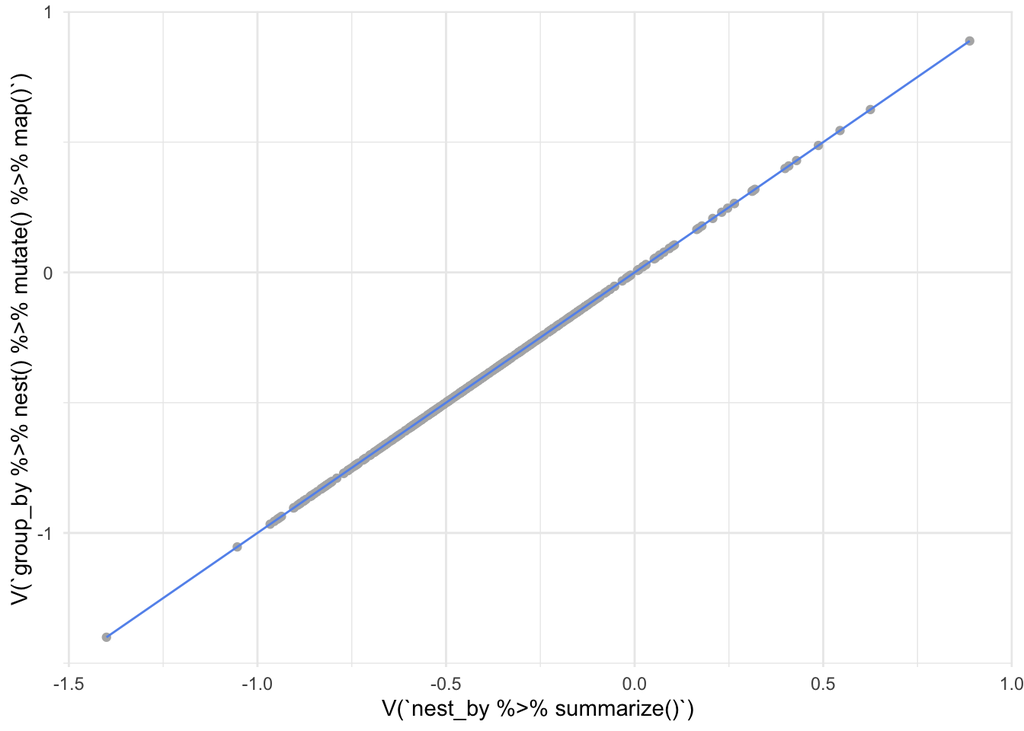

```r
diff1 %>%
  rename(v1 = v) %>%
  left_join(diff2) %>%
  rename(v2 = v) %>%
  ggplot(aes(v2, v1)) +
  geom_point(color = "gray70") +
  geom_line(color = "cornflowerblue") +
  scale_y_continuous(
        breaks = c(-1.0, 0.0, 1.0)
    ) +
  xlab("V(`nest_by %>% summarize()`)") +
  ylab("V(`group_by %>% nest() %>% mutate() %>% map()`)") +
  theme_minimal()
```

### Question 3

Produce a similar plot for each of the first 100 school districts. Once you’ve created all the plots, **reproduce them again using an alternative method**. Make sure you don’t miss the caption noting the number of schools in the district.

Hint: You need to select unique *districts.* You may want to try something like the following:

```r
# fix district names

#visual inspection of districts name suggests that most end with SD (short for School District) followed by a number. We want to get rid of everything after SD, and replace it with School District

diff1$district_name <- gsub(x = diff1$district,
                            pattern = "SD.+", "School District")

#select 100 districts

dists <- unique(diff1$district_name)[1:100]
```

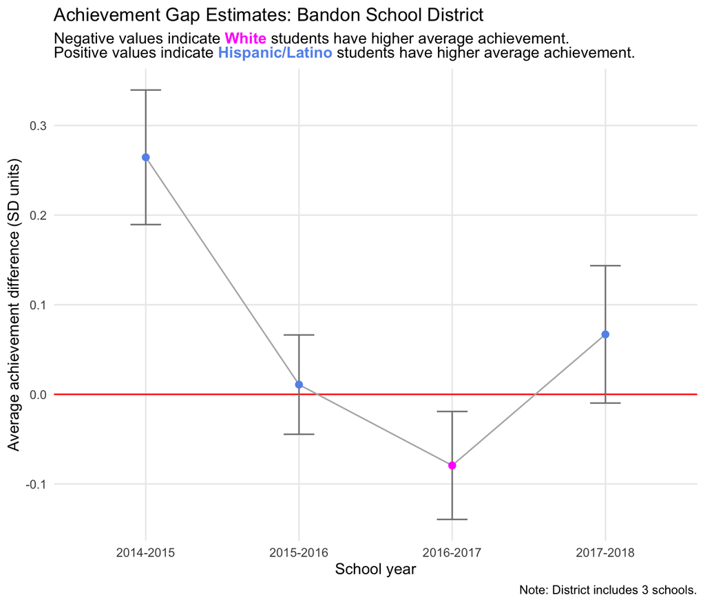

```r
#re-creating for individual district
#it works

diff1 %>%
    filter(district_name == "Bandon School District") %>%
    mutate(
        color = ifelse(v >= 0, TRUE, FALSE)
    ) %>%
    ggplot(aes(x = academic_year,
               y = v,
               group = district_name)) +
    geom_hline(aes(yintercept = 0),
               color = "red") +
    geom_line(color = "gray70") +
    geom_errorbar(aes(ymin = v - 1.96 * v_se,
                      ymax = v + 1.96 * v_se),
                      width = 0.2,
                      color = "gray50"
    ) +
    geom_point(aes(color = color),
               size = 2,
               show.legend = FALSE) +
    scale_color_manual(
        values = c("magenta", "cornflowerblue")) +
    labs(
        x = "School year",
        y = "Average achievement difference (SD units)",
        title = "Achievement Gap Estimates: Bandon School District",
        subtitle = "Negative values indicate <span style = 'color: #FF00FF'>**White**</span> students have higher average achievement. <br>
        Positive values indicate <span style = 'color: #6495ED'>**Hispanic/Latino**</span> students have higher average achievement.",
        caption = "Note: District includes 3 schools."
    ) +
    theme_minimal() +
    theme(
        panel.grid.minor = element_blank(),
        plot.subtitle = ggtext::element_markdown()
    )
```

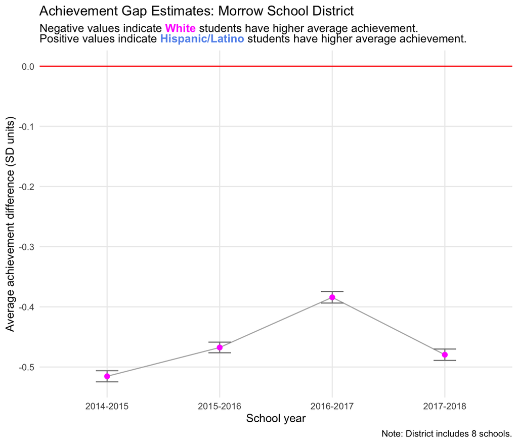

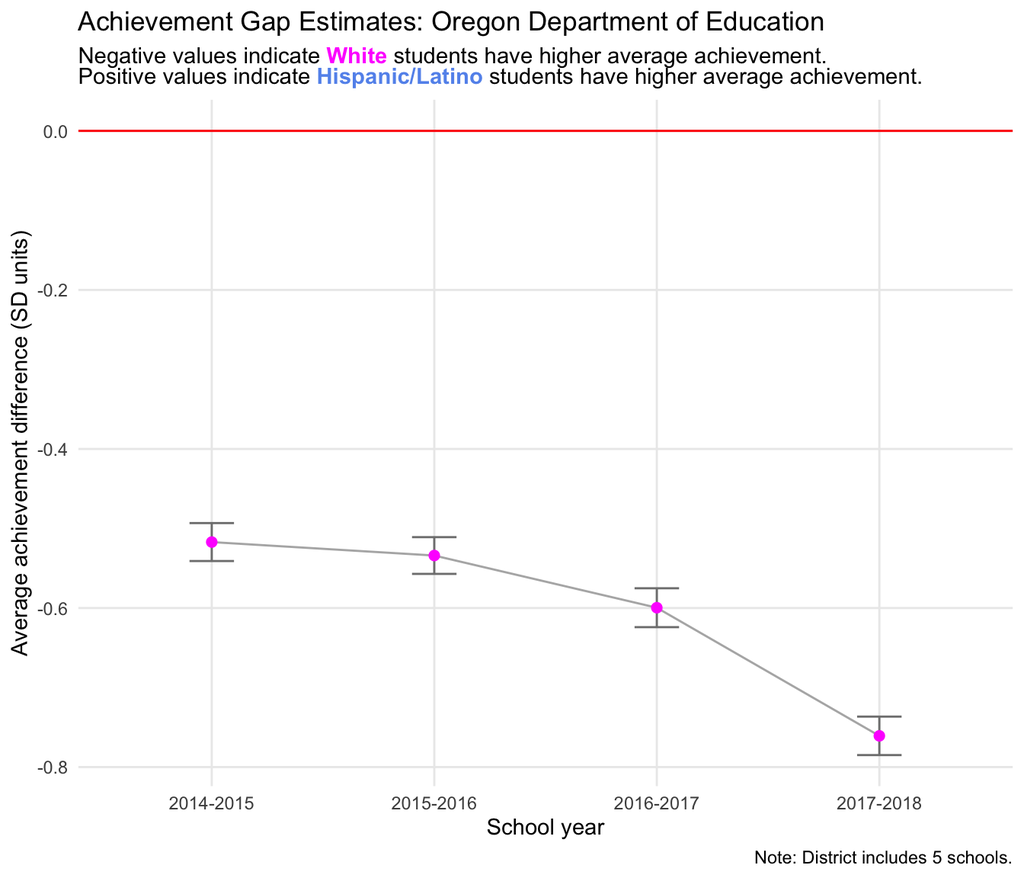

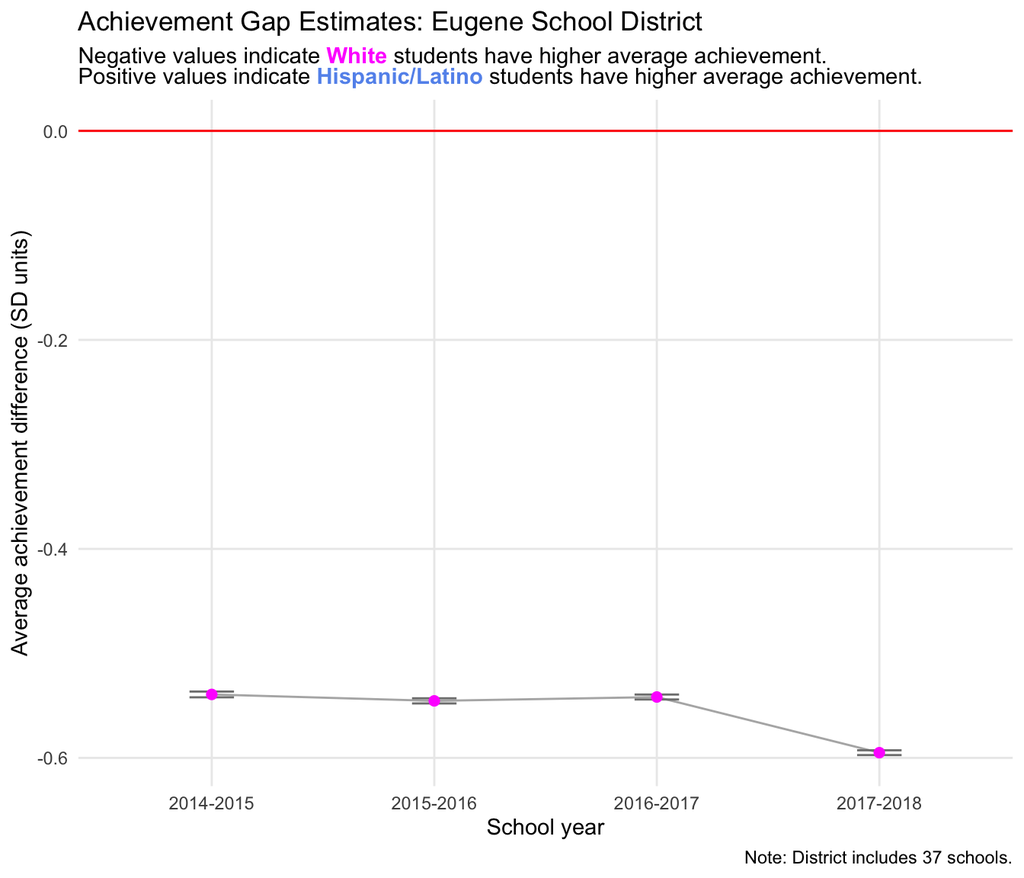

```r
#getting back numb_school in the df
diff1 <- diff1 %>%
    left_join(unique(data2[,c('numb_schools','district')]), by = 'district')

#creating all plots
#method 1

plots1 <- diff1 %>%
        filter(district_name %in% dists) %>%
        mutate(
        color = ifelse(v >= 0, TRUE, FALSE)
        ) %>%
        group_by(district_name, numb_schools) %>%
        nest() %>%
        mutate(
            plot = pmap(
                list(data, district_name, numb_schools),
                ~{
                     ggplot(..1, aes(x = academic_year,
                                     y = v,
                                     group = district)) +
    geom_hline(aes(yintercept=0),
               color = "red") +
    geom_line(color = "gray70") +
    geom_errorbar(aes(ymin = v - 1.96 * v_se,
                      ymax = v + 1.96 * v_se),
                      width = 0.2,
                  color = "gray50"
    ) +
    geom_point(aes(color = color),
               size = 2,
               show.legend = FALSE) +
    scale_color_manual(
        values = c("magenta", "cornflowerblue")) +
    labs(
        x = "School year",
        y = "Average achievement difference (SD units)",
        title = glue("Achievement Gap Estimates: {..2}"),
        subtitle = "Negative values indicate <span style = 'color: #FF00FF'>**White**</span> students have higher average achievement. <br>
        Positive values indicate <span style = 'color: #6495ED'>**Hispanic/Latino**</span> students have higher average achievement.",
        caption = glue("Note: District includes {..3} schools.")
    ) +
    theme_minimal() +
    theme(
        panel.grid.minor = element_blank(),
        plot.subtitle = ggtext::element_markdown()
    )
                }
        )
        )

#let's randomly see some plots
r <- sample(1:100, 3)

for(i in r){
    print(plots1$plot[[i]])
}
```

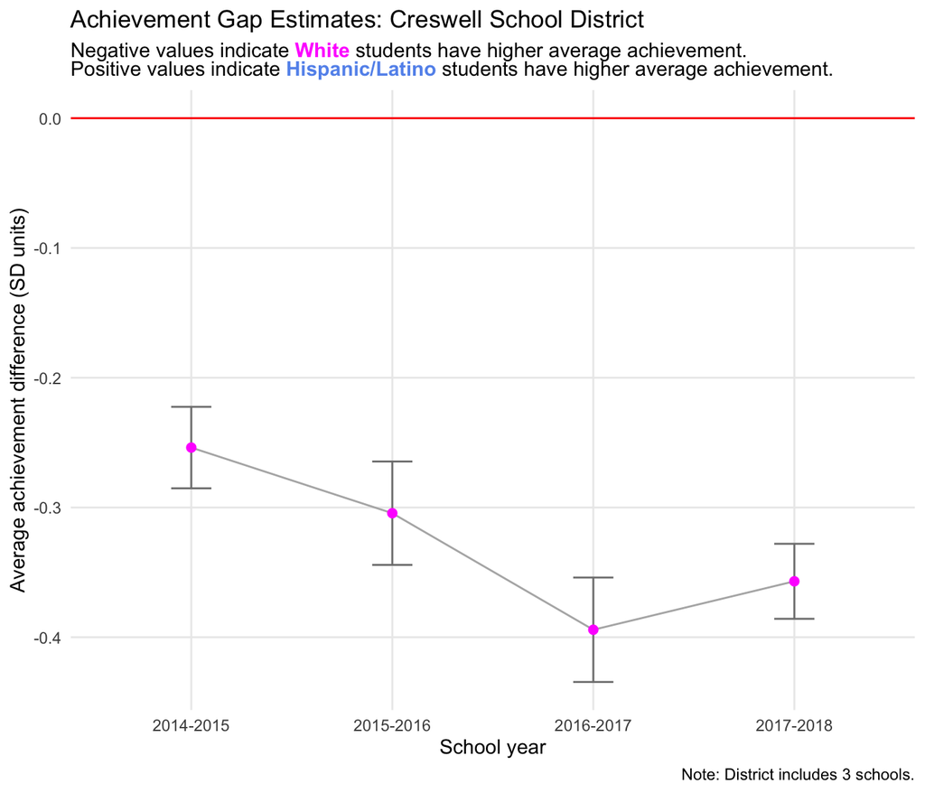

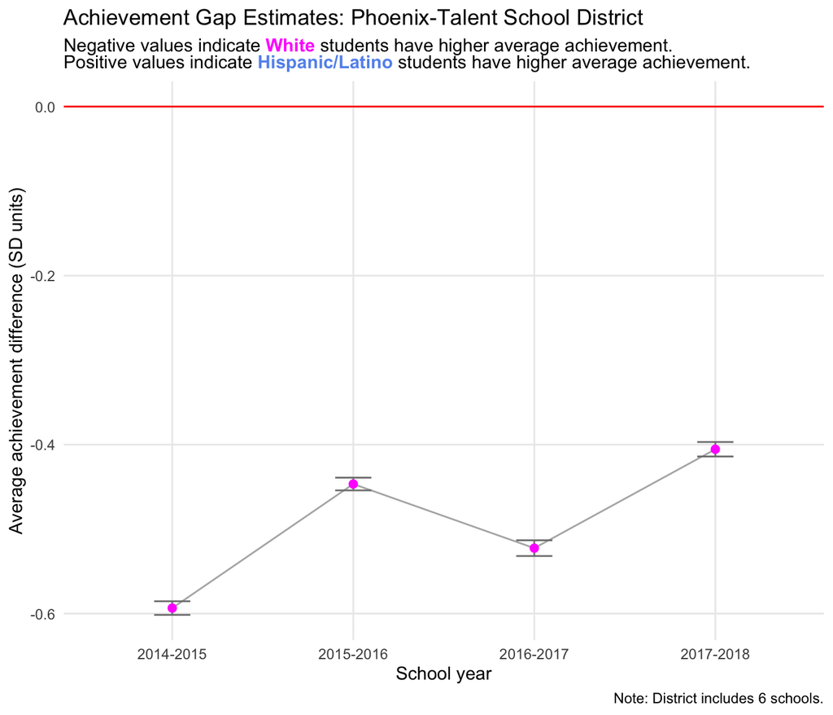

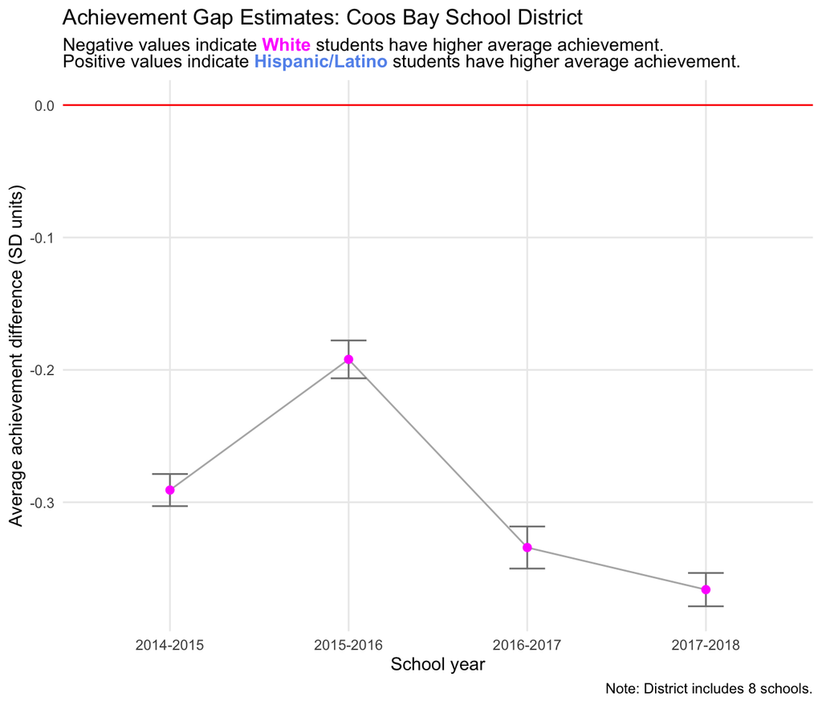

```r
#creating all plots
#method 2

plots2 <- diff1 %>%
        filter(district_name %in% dists) %>%
        mutate(
        color = ifelse(v >= 0, TRUE, FALSE)
        ) %>%
        ungroup() %>%
        nest_by(district_name, numb_schools) %>%
        mutate(
            plot = list(
                    ggplot(data,
                            aes(x = academic_year,
                                y = v,
                                group = district)) +
                    geom_hline(aes(yintercept = 0),
                               color = "red") +
                    geom_line(color = "gray70") +
                    geom_errorbar(aes(
                                ymin = v - 1.96 * v_se,
                                ymax = v + 1.96 * v_se),
                                width = 0.2,
                                color = "gray50") +
                    geom_point(aes(color = color),
                           size = 2,
                           show.legend = FALSE) +
                    scale_color_manual(
                        values = c("magenta", "cornflowerblue")) +
                    labs(
                        x = "School year",
                        y = "Average achievement difference (SD units)",
                        title = glue("Achievement Gap Estimates: {district_name}"),
                        subtitle = "Negative values indicate <span style = 'color: #FF00FF'>**White**</span> students have higher average achievement. <br>
                        Positive values indicate <span style = 'color: #6495ED'>**Hispanic/Latino**</span> students have higher average achievement.",
                        caption = glue("Note: District includes {numb_schools} schools.")
                    ) +
                    theme_minimal() +
                    theme(
                        panel.grid.minor = element_blank(),
                        plot.subtitle = ggtext::element_markdown()
                    )
                )
        )

#let's randomly see some plots
r <- sample(1:100, 3)

for(i in r){
    print(plots2$plot[[i]])
}
```

#### Extra Credit

For up to 1 point extra credit, create a third set that “staples together” each of the preceding pairs of plots (i.e., to confirm that the plots were produced identically by both methods).

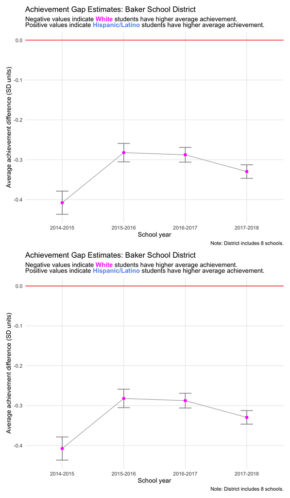

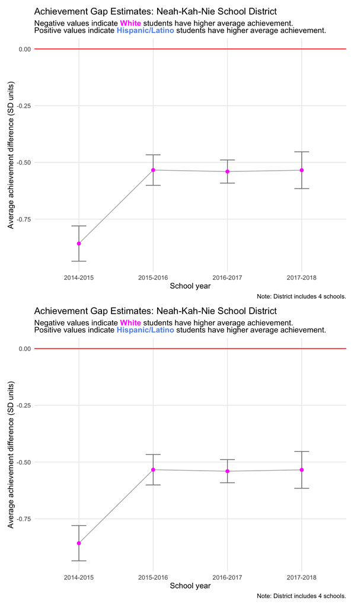

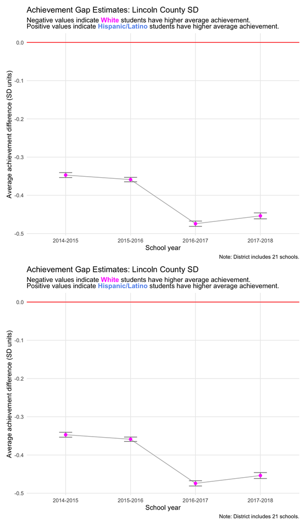

```r
combine <- map2(plots1$plot,plots2$plot, ~.x / .y)

#let's randomly see some plots
r <- sample(1:100, 3)

for(i in r){
    print(combine[[i]])
}
```

### Question 4

Save the plots into a “plots” directory. Make sure the file names are meaningful.

```r
fs::dir_create(here::here("plots"))

files <- str_replace_all(
  tolower(plots1$district_name),
  " ",
  "-"
)

paths <- here::here("plots", glue("{files}.png"))
#paths


walk2(paths, plots1$plot, ggsave,
      width = 7,
      height = 6,
      dpi = 400)
```